# Informative Bayesian priors in a clinical intervention study

Individual project for Bayesian Analysis and Decision Theory, Spring 2022

Carl Delfin

2022-02-15

# 1 Preparations

## 1.1 Libraries

```r
library(here)
library(tidyverse)
library(tidybayes)
library(brms)
library(rstan)
library(emmeans)
library(knitr)
library(kableExtra)
```

## 1.2 Setup

```r
# overwrite brms models?
overwrite <- FALSE

# brms settings
refresh <- 0
cores <- 4
chains <- 4
iter <- 4000
warmup <- 1000

# how large are our groups?
n <- 25
```

## 1.3 Functions

A few helper functions are necessary.

```r
# sample from a truncated normal distribution
# https://stats.stackexchange.com/a/510821
rnormt <- function(n, range, mu, sigma) {
  pnorm_min <- pnorm(min(range), mean = mu, sd = sigma)
  pnorm_max <- pnorm(max(range), mean = mu, sd = sigma)
  unif = runif(n, min = pnorm_min, max = pnorm_max)
  qnorm(unif, mean = mu, sd = sigma)
}

# ggplot theme in line with LU colors
theme_lu <- function() {
    theme_classic() +
    theme(plot.title = element_text(size = 14, color = "#202020"),
          plot.subtitle = element_text(size = 11, color = "#202020"),
          plot.caption = element_text(size = 11, color = "#202020"),
          axis.text = element_text(size = 11, color = "#202020"),
          axis.text.x = element_text(size = 11, color = "#202020"),
          axis.text.y = element_text(size = 11, color = "#202020"),
          legend.title = element_text(size = 11),
          legend.text = element_text(size = 11),
          panel.grid.major = element_line(color = "#bcbab4", size = 0.2),
          panel.background = element_rect(fill = "#ebe9e2", color = "#ebe9e2"),
          plot.background = element_rect(fill = "#ebe9e2", color = "#ebe9e2"),
          strip.background = element_rect(fill = "#e7e6e4"),
          strip.text = element_text(colour = "#202020"),
          legend.key = element_rect(fill = NA, color = NA),
          legend.background = element_rect(color = NA, fill = NA),
          legend.position = "top")
}

# mimic emmeans output for rstan models
# NOTE: this is not a generic function,
# it will only work for models specified here
rstan_emmeans <- function(model, type = "means") {
    # gather posterior samples
    post <- as.data.frame(model) %>%
        dplyr::select(b_Intercept, `b[1]`, `b[2]`, `b[3]`, `b[4]`, `b[5]`)

    # if type = 'means' then print means and 95% HDIs
    if (type == "means") {
        out <- rbind(mean_hdi(post[, 1]),
                     mean_hdi(post[, 1] + post[, 2]),
                     mean_hdi(post[, 1] + post[, 3]),

                     mean_hdi(post[, 1] + post[, 4]),
                     mean_hdi(post[, 1] + post[, 4] + post[, 2] + post[, 5]),
                     mean_hdi(post[, 1] + post[, 4] + post[, 3] + post[, 6])) %>%
        mutate(time = paste0("t", rep(1:3, times = 2)),
               group = rep(c("control", "intervention"), each = 3, times = 1)) %>%
        mutate_if(is.numeric, round, 2) %>%
        dplyr::select(group, time, y, ymin, ymax)
        print(out)

    # if type = 'contrasts' then mimic emmeans pairs output,
    # with estimated difference and 95% HDI
    } else if (type == "contrasts") {
        out <- rbind(mean_hdi(post[, 2]),
                     mean_hdi(post[, 3]),
                     mean_hdi(post[, 3] - post[, 2]),

                     mean_hdi(post[, 5] + post[, 2]),
                     mean_hdi(post[, 3] + post[, 6]),
                     mean_hdi(post[, 6] - post[, 5] + post[, 3] - post[, 2])) %>%
        mutate(contrast = rep(c("t2 - t1", "t3 - t1", "t3 - t2"), each = 1, times = 2),
               group = rep(c("control", "intervention"), each = 3, times = 1)) %>%
        mutate_if(is.numeric, round, 2) %>%
        dplyr::select(group, contrast, y, ymin, ymax)
        print(out)
    } else {
        stop("type must be one of 'means' or 'contrasts'")
    }
}
```

# 2 Data

Let’s simulate some data representing the *mean initial thinking time* (MITT) from the [Stockings of Cambridge](https://www.cambridgecognition.com/cantab/cognitive-tests/executive-function/stockings-of-cambridge-soc/) (SoC) task, a computerized variant of the famous [Tower of Hanoi](https://en.wikipedia.org/wiki/Tower_of_Hanoi) problem-solving task. In the SoC, participants are tasked with trying to copy a pattern of balls shown on the screen by moving one ball at a time between three “stockings”. They are also asked to figure out a solution *before* starting to move any balls, and the time spent thinking about a solution before touching the screen is the MITT. In essence, the MITT is a measure of impulsivity or [disinhibition](https://en.wikipedia.org/wiki/Disinhibition), and the idea is that the intervention group receives some form of training that will improve their ability to think before acting.

Based on a [previous study](https://www.frontiersin.org/articles/10.3389/fpsyt.2018.00310/full) of mine, it seems reasonable to assume that the average MITT in violent offenders is six seconds, with a standard deviation of five and with possible scores ranging from 0 to 30. To make group differences distinguishable yet somewhat realistic, we’ll simulate data with an approximate effect size (Cohen’s *d*) of 1 for the difference in MITT between T1 and T3 in the intervention group. Note that in order to keep simulated values within the specified range we must sample from a truncated normal distribution (`rnormt`), the code for which is available above.

```r
set.seed(2022)
c1 <- round(rnormt(n, c(0, 30), 6, 5), 0)
c2 <- c1 * 1.01 + rnormt(n, c(-3, 3), 0, 5)
c3 <- c2 * 1.01 + rnormt(n, c(-3, 3), 0, 5)

i1 <- round(rnormt(n, c(0, 30), 6, 5), 0)
i2 <- i1 * 1.2 + rnormt(n, c(-3, 3), 0, 5)
i3 <- i2 * 1.4 + rnormt(n, c(-3, 3), 0, 5)

d <- data.frame(id = seq(1, n * 2, 1),
                group = rep(c("control", "intervention"), each = n),
                t1 = c(c1, i1),
                t2 = c(c2, i2),
                t3 = c(c3, i3)) %>%
    mutate_if(is.numeric, round, 0) %>%
    gather("time", "mitt", t1, t2, t3) %>%
    # make sure there are no zero values for mitt
    mutate(mitt = ifelse(mitt < 0, 1, mitt))
```

## 2.1 Data format

Here’s what the first and last six rows of data look like:

```r
head(d); tail(d)
```

```
##   id   group time mitt
## 1  1 control   t1   11
## 2  2 control   t1    8
## 3  3 control   t1    2
## 4  4 control   t1    7
## 5  5 control   t1    3
## 6  6 control   t1    8
```

```
##     id        group time mitt
## 145 45 intervention   t3   14
## 146 46 intervention   t3    4
## 147 47 intervention   t3    3
## 148 48 intervention   t3   30
## 149 49 intervention   t3   12
## 150 50 intervention   t3   15
```

## 2.2 Visual overview

Here’s a visual overview of the simulated data:

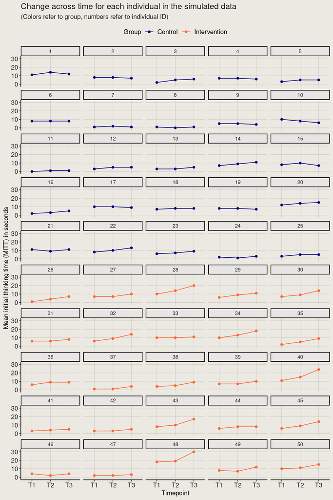

```r
d %>%
  ggplot(aes(x = time, y = mitt, color = group, group = group)) +
  geom_point() +
  geom_line() +
  coord_cartesian(ylim = c(0, 30)) +
  labs(title = "Change across time for each individual in the simulated data",
       subtitle = "(Colors refer to group, numbers refer to individual ID)",
       y = "Mean initial thinking time (MITT) in seconds", x = "Timepoint",
       color = "Group",
       fill = "Group") +
  facet_wrap(~ id, nrow = 10) +
  scale_x_discrete(labels = c("T1", "T2", "T3")) +
  scale_y_continuous(expand = c(0.1, 0.1)) +
  scale_color_manual(labels = c("Control", "Intervention"), values = c("#000080", "#ff6735")) +
  theme_lu()
```

## 2.3 Means and SDs

Here are means and standard deviations. These will serve as “ground truth” for model comparisons later on.

```r
means_and_sds <- d %>%
    group_by(time, group) %>%
    dplyr::summarise(mean = paste0(mean(mitt), " (", round(sd(mitt), 2), ")")) %>%
    tidyr::spread(time, mean) %>%
    as.data.frame() %>%
    select(-group)

means <- d %>%
    na.omit() %>%
    group_by(time, group) %>%
    dplyr::summarise(mean = mean(mitt)) %>%
    tidyr::spread(time, mean) %>%
    as.data.frame()

between_grp_diff <- means[2, 2:4] - means[1, 2:4]

table_1 <- rbind(means_and_sds, round(between_grp_diff, 2))

rownames(table_1) <- c("Control", "Intervention", "Between-group difference")
table_1 %>%
    kbl(caption = "Table 1. Means (SDs) and between-group differences for the simulated data.",
        col.names = c("T1", "T2", "T3"),
        full.width = FALSE) %>%
    kable_styling(bootstrap_options = "condensed",
                  font_size = 17)
```

Table 1. Means (SDs) and between-group differences for the simulated data.

|  | T1 | T2 | T3 |
| --- | --- | --- | --- |
| Control | 5.84 (3.6) | 6.6 (3.72) | 6.8 (3.66) |
| Intervention | 6.48 (3.8) | 7.92 (4.36) | 11.64 (6.49) |
| Between-group difference | 0.64 | 1.32 | 4.84 |

```r
table_2 <- data.frame(
    t2_t1 = c(means[1, 3] - means[1, 2], means[2, 3] - means[2, 2]),
    t3_t2 = c(means[1, 4] - means[1, 3], means[2, 4] - means[2, 3]),
    t3_t1 = c(means[1, 4] - means[1, 2], means[2, 4] - means[2, 2]))
rownames(table_2) <- c("Control", "Intervention")

table_2 %>%
    kbl(caption = "Table 2. Within-group differences for the simulated data.",
        col.names = c("T2 minus T1", "T3 minus T2", "T3 minus T1"),
        full.width = FALSE) %>%
    kable_styling(bootstrap_options = "condensed",
                  font_size = 17)
```

Table 2. Within-group differences for the simulated data.

|  | T2 minus T1 | T3 minus T2 | T3 minus T1 |
| --- | --- | --- | --- |
| Control | 0.76 | 0.20 | 0.96 |
| Intervention | 1.44 | 3.72 | 5.16 |

# 3 Adding some chaos

Clinical data is rarely perfect. Participants may drop out or provide extreme values. To add some chaos to our measurements, we’ll randomly add some missing data, say, 30%, or 45 measurements. In addition, let’s manually change two values to act as “outliers”. These may be thought of participants that had unusually high or low MITT values at T3.

```r
n_missing <- 45
dm <- d
set.seed(2022)
dm[sample(150, n_missing), "mitt"] <- rep(NA, n_missing)

dm[108, "mitt"] <- 64 # previously had 1
dm[148, "mitt"] <- 1 # previously had 30
```

Now, participants 6 and 12 are completely missing. Maybe some technical difficulties made their data corrupt? Participants 8 and 48 were given very high and very low values at T3, respectively. In addition, relatively few participants now have complete data, with measurements at each timepoint. Here’s what the new data looks like:

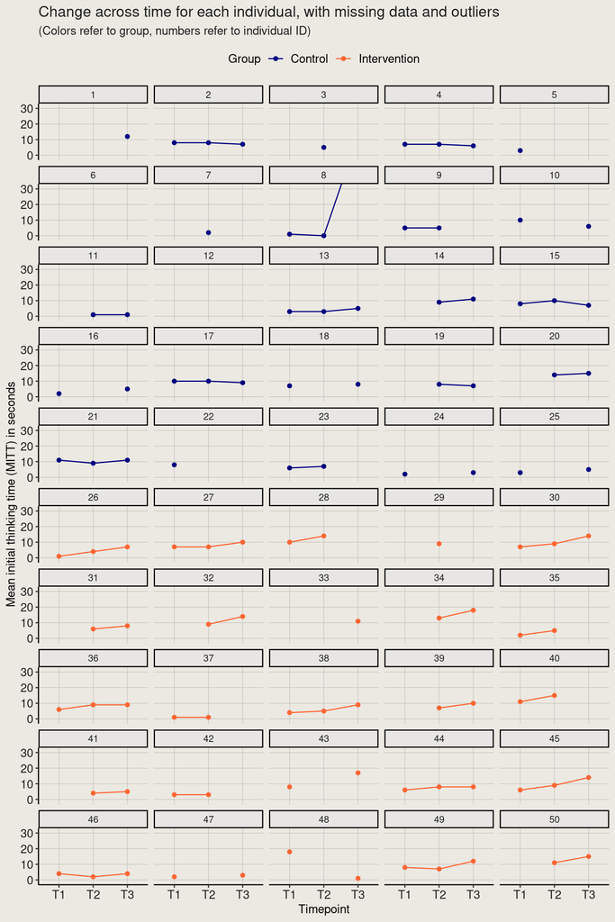

```r
dm %>%
  ggplot(aes(x = time, y = mitt, color = group, group = group)) +
  geom_point() +
  geom_line() +
  coord_cartesian(ylim = c(0, 30)) +
  labs(title = "Change across time for each individual, with missing data and outliers",
       subtitle = "(Colors refer to group, numbers refer to individual ID)",
       y = "Mean initial thinking time (MITT) in seconds", x = "Timepoint",
       color = "Group",
       fill = "Group") +
  facet_wrap(~ id, nrow = 10) +
  scale_x_discrete(labels = c("T1", "T2", "T3")) +
  scale_y_continuous(expand = c(0.1, 0.1)) +
  scale_color_manual(labels = c("Control", "Intervention"), values = c("#000080", "#ff6735")) +
  theme_lu()
```

# 4 Bayesian models

Time to model!

## 4.1 m1

Regular linear regression with *default* priors:

```r
if (overwrite == TRUE) {
    m1 <- brm(mitt ~ 1 + time * group,
              data = dm,
              family = gaussian,
              seed = 2022,
              refresh = refresh,
              chains = chains,
              cores = cores,
              iter = iter,
              warmup = warmup)
    saveRDS(m1, here::here("tmp/m1.rds"))
}

m1 <- readRDS(here::here("tmp/m1.rds"))
print(m1)
```

```
##  Family: gaussian
##   Links: mu = identity; sigma = identity
## Formula: mitt ~ 1 + time * group
##    Data: dm (Number of observations: 105)
##   Draws: 4 chains, each with iter = 4000; warmup = 1000; thin = 1;
##          total post-warmup draws = 12000
##
## Population-Level Effects:
##                          Estimate Est.Error l-95% CI u-95% CI Rhat Bulk_ESS Tail_ESS
## Intercept                    5.84      1.68     2.52     9.15 1.00     6472     7361
## timet2                       0.64      2.45    -4.14     5.49 1.00     6183     7130
## timet3                       4.82      2.35     0.26     9.48 1.00     6809     7996
## groupintervention            0.26      2.33    -4.24     4.88 1.00     5760     6866
## timet2:groupintervention     0.71      3.26    -5.76     7.04 1.00     5932     6566
## timet3:groupintervention    -0.98      3.25    -7.40     5.39 1.00     6070     7213
##
## Family Specific Parameters:
##       Estimate Est.Error l-95% CI u-95% CI Rhat Bulk_ESS Tail_ESS
## sigma     6.79      0.49     5.93     7.85 1.00     9621     7827
##
## Draws were sampled using sampling(NUTS). For each parameter, Bulk_ESS
## and Tail_ESS are effective sample size measures, and Rhat is the potential
## scale reduction factor on split chains (at convergence, Rhat = 1).
```

Estimated marginal means:

```r
m1_em <- emmeans(m1, ~ time | group)
summary(m1_em, point.est = "mean")
```

```
## group = control:
##  time emmean lower.HPD upper.HPD
##  t1     5.84      2.38      9.00
##  t2     6.49      3.12     10.06
##  t3    10.67      7.58     13.87
##
## group = intervention:
##  time emmean lower.HPD upper.HPD
##  t1     6.11      2.91      9.29
##  t2     7.46      4.55     10.27
##  t3     9.95      6.95     13.06
##
## Point estimate displayed: mean
## HPD interval probability: 0.95
```

```r
summary(pairs(m1_em, type = "response", reverse = TRUE), point.est = "mean")
```

```
## group = control:
##  contrast estimate lower.HPD upper.HPD
##  t2 - t1     0.643    -4.152      5.48
##  t3 - t1     4.820     0.150      9.35
##  t3 - t2     4.177    -0.392      8.92
##
## group = intervention:
##  contrast estimate lower.HPD upper.HPD
##  t2 - t1     1.355    -3.207      5.35
##  t3 - t1     3.839    -0.687      8.17
##  t3 - t2     2.484    -1.647      6.68
##
## Point estimate displayed: mean
## HPD interval probability: 0.95
```

## 4.2 m2

Varying intercepts with *weakly informative* priors:

```r
if (overwrite == TRUE) {
    m2 <- brm(mitt ~ 1 + time * group + (1 | id),
              data = dm,
              family = gaussian,
              prior = c(prior(normal(0, 10), class = "b"),
                        prior(normal(6, 10), class = "Intercept"),
                        prior(cauchy(0, 1), class = "sigma"),
                        prior(cauchy(0, 1), class = "sd")),
              seed = 2022,
              refresh = refresh,
              chains = chains,
              cores = cores,
              iter = iter,
              warmup = warmup)
    saveRDS(m2, here::here("tmp/m2.rds"))
}

m2 <- readRDS(here::here("tmp/m2.rds"))
print(m2)
```

```
##  Family: gaussian
##   Links: mu = identity; sigma = identity
## Formula: mitt ~ 1 + time * group + (1 | id)
##    Data: dm (Number of observations: 105)
##   Draws: 4 chains, each with iter = 4000; warmup = 1000; thin = 1;
##          total post-warmup draws = 12000
##
## Group-Level Effects:
## ~id (Number of levels: 48)
##               Estimate Est.Error l-95% CI u-95% CI Rhat Bulk_ESS Tail_ESS
## sd(Intercept)     0.81      0.67     0.03     2.50 1.00     6835     7135
##
## Population-Level Effects:
##                          Estimate Est.Error l-95% CI u-95% CI Rhat Bulk_ESS Tail_ESS
## Intercept                    6.03      1.60     2.92     9.19 1.00    10838    10648
## timet2                       0.46      2.26    -3.92     4.91 1.00    12644     9603
## timet3                       4.50      2.22     0.09     8.84 1.00    11964     9527
## groupintervention            0.12      2.19    -4.15     4.43 1.00    10106     9712
## timet2:groupintervention     0.86      2.99    -5.10     6.54 1.00    11049     9498
## timet3:groupintervention    -0.68      3.01    -6.55     5.25 1.00    11479     9145
##
## Family Specific Parameters:
##       Estimate Est.Error l-95% CI u-95% CI Rhat Bulk_ESS Tail_ESS
## sigma     6.73      0.50     5.82     7.79 1.00    15049     7113
##
## Draws were sampled using sampling(NUTS). For each parameter, Bulk_ESS
## and Tail_ESS are effective sample size measures, and Rhat is the potential
## scale reduction factor on split chains (at convergence, Rhat = 1).
```

Estimated marginal means:

```r
m2_em <- emmeans(m2, ~ time | group)
summary(m2_em, point.est = "mean")
```

```
## group = control:
##  time emmean lower.HPD upper.HPD
##  t1     6.03      2.91      9.18
##  t2     6.49      3.13      9.81
##  t3    10.53      7.31     13.62
##
## group = intervention:
##  time emmean lower.HPD upper.HPD
##  t1     6.15      2.97      9.21
##  t2     7.47      4.51     10.26
##  t3     9.97      7.05     13.07
##
## Point estimate displayed: mean
## HPD interval probability: 0.95
```

```r
summary(pairs(m2_em, type = "response", reverse = TRUE), point.est = "mean")
```

```
## group = control:
##  contrast estimate lower.HPD upper.HPD
##  t2 - t1     0.461    -3.875      4.94
##  t3 - t1     4.503     0.254      8.99
##  t3 - t2     4.042    -0.703      8.44
##
## group = intervention:
##  contrast estimate lower.HPD upper.HPD
##  t2 - t1     1.320    -2.644      5.59
##  t3 - t1     3.825    -0.471      8.01
##  t3 - t2     2.505    -1.670      6.56
##
## Point estimate displayed: mean
## HPD interval probability: 0.95
```

## 4.3 m3

Varying intercepts with *weakly informative* priors, a *lower bound* of zero on `Intercept` since MITT can’t be negative, and a *robust response distribution* accounting for outliers:

```r
if (overwrite == TRUE) {
    m3_spec <- brm(mitt ~ 1 + time * group + (1 | id),
                   data = dm,
                   family = student,
                   prior = c(prior(normal(0, 10), class = "b"),
                             prior(normal(6, 10), class = "Intercept"),
                             prior(cauchy(0, 1), class = "sigma"),
                             prior(cauchy(0, 1), class = "sd")),
                   empty = TRUE)

    # must do this in stan code since brms doesn't accept lower bound on coefs
    stan_code <- stancode(m3_spec)
    stan_code <- gsub("real Intercept;", "real<lower=0> Intercept;", stan_code)
    stan_data <- make_standata(formula = mitt ~ 1 + time * group + (1 | id),
                               data = dm,
                               family = gaussian)

    m3 <- stan(model_code = stan_code,
               data = stan_data,
               seed = 2022,
               refresh = refresh,
               chains = chains,
               cores = cores,
               iter = iter,
               warmup = warmup)
    saveRDS(m3, here::here("tmp/m3.rds"))
}

m3 <- readRDS(here::here("tmp/m3.rds"))
print(m3, pars = c("b_Intercept", "b[1]", "b[2]", "b[3]", "b[4]", "b[5]"))
```

```
## Inference for Stan model: ac4eaa6997563236b5912e70d9cb546b.
## 4 chains, each with iter=4000; warmup=1000; thin=1;
## post-warmup draws per chain=3000, total post-warmup draws=12000.
##
##              mean se_mean   sd  2.5%   25%   50%  75% 97.5% n_eff Rhat
## b_Intercept  6.18    0.02 0.87  4.48  5.60  6.19 6.76  7.88  1706    1
## b[1]         0.13    0.01 0.56 -0.96 -0.25  0.13 0.49  1.23  6153    1
## b[2]         0.44    0.01 0.59 -0.71  0.03  0.44 0.83  1.61  6127    1
## b[3]        -0.46    0.03 1.23 -2.88 -1.26 -0.47 0.35  1.99  1781    1
## b[4]         1.42    0.01 0.83 -0.25  0.87  1.43 1.98  3.04  5261    1
## b[5]         4.16    0.01 0.93  2.38  3.54  4.17 4.78  5.98  5169    1
##
## Samples were drawn using NUTS(diag_e) at Tue Feb 15 15:45:52 2022.
## For each parameter, n_eff is a crude measure of effective sample size,
## and Rhat is the potential scale reduction factor on split chains (at
## convergence, Rhat=1).
```

Estimated marginal means (using a custom function for `rstan` models, see above):

```r
rstan_emmeans(m3, type = "means")
```

```
##          group time     y ymin  ymax
## 1      control   t1  6.18 4.46  7.85
## 2      control   t2  6.31 4.51  7.97
## 3      control   t3  6.62 4.97  8.42
## 4 intervention   t1  5.72 4.02  7.51
## 5 intervention   t2  7.27 5.61  8.91
## 6 intervention   t3 10.32 8.51 12.09
```

```r
rstan_emmeans(m3, type = "contrasts")
```

```
##          group contrast    y  ymin ymax
## 1      control  t2 - t1 0.13 -0.97 1.21
## 2      control  t3 - t1 0.44 -0.68 1.63
## 3      control  t3 - t2 0.31 -0.85 1.52
## 4 intervention  t2 - t1 1.55  0.32 2.75
## 5 intervention  t3 - t1 4.60  3.16 6.02
## 6 intervention  t3 - t2 3.05  1.89 4.19
```

## 4.4 m4

Varying intercepts with *informative* priors on *within-group* differences, a *lower bound* of zero on `Intercept`, and a *robust response distribution* accounting for outliers:

```r
if (overwrite == TRUE) {
    m4_spec <- brm(mitt ~ 1 + time * group + (1 | id),
                   stanvars = stanvar(scode = "real diff_t3_t2;
                                               real diff_t2_t1;
                                               real diff_t3_t1;
                                               diff_t3_t2 = b[5] - b[4] + b[2] - b[1];
                                               diff_t2_t1 = b[4] + b[1];
                                               diff_t3_t1 = b[2] + b[5];",
                                      block = "tparameters") +
                   stanvar(scode = "target += normal_lpdf(diff_t3_t2 | 4, 4);
                                    target += normal_lpdf(diff_t2_t1 | 1.5, 4);
                                    target += normal_lpdf(diff_t3_t1 | 5, 4);",
                           block = "model"),
                   data = dm,
                   family = student,
                   prior = c(prior(normal(0, 10), class = "b"),
                             prior(normal(10, 1), class = "Intercept"),
                             prior(cauchy(0, 1), class = "sigma"),
                             prior(cauchy(0, 1), class = "sd"),
                             prior(gamma(2, 0.1), class = "nu")),
                   empty = TRUE)

    stan_code <- stancode(m4_spec)
    stan_code <- gsub("real Intercept;", "real<lower=0> Intercept;", stan_code)
    stan_data <- make_standata(formula = mitt ~ 1 + time * group + (1 | id),
                               data = dm,
                               family = student)

    m4 <- stan(model_code = stan_code,
               data = stan_data,
               seed = 2022,
               refresh = refresh,
               chains = chains,
               cores = cores,
               iter = iter,
               warmup = warmup)
    saveRDS(m4, here::here("tmp/m4.rds"))
}

m4 <- readRDS(here::here("tmp/m4.rds"))
print(m4, pars = c("b_Intercept", "b[1]", "b[2]", "b[3]", "b[4]", "b[5]"))
```

```
## Inference for Stan model: 32ff518c9ba306bfa49f6a087400ddd4.
## 4 chains, each with iter=4000; warmup=1000; thin=1;
## post-warmup draws per chain=3000, total post-warmup draws=12000.
##
##              mean se_mean   sd  2.5%   25%   50%  75% 97.5% n_eff Rhat
## b_Intercept  6.81    0.02 0.84  5.23  6.24  6.79 7.35  8.51  2256    1
## b[1]         0.12    0.01 0.56 -0.99 -0.24  0.11 0.48  1.25  7835    1
## b[2]         0.44    0.01 0.59 -0.72  0.04  0.43 0.83  1.60  7017    1
## b[3]        -0.35    0.03 1.27 -2.86 -1.18 -0.35 0.46  2.15  2024    1
## b[4]         1.41    0.01 0.82 -0.22  0.87  1.41 1.96  3.00  6233    1
## b[5]         4.21    0.01 0.93  2.40  3.57  4.20 4.83  6.04  5611    1
##
## Samples were drawn using NUTS(diag_e) at Tue Feb 15 15:46:49 2022.
## For each parameter, n_eff is a crude measure of effective sample size,
## and Rhat is the potential scale reduction factor on split chains (at
## convergence, Rhat=1).
```

Estimated marginal means:

```r
rstan_emmeans(m4, type = "means")
```

```
##          group time     y ymin  ymax
## 1      control   t1  6.81 5.12  8.39
## 2      control   t2  6.93 5.32  8.65
## 3      control   t3  7.25 5.66  8.94
## 4 intervention   t1  6.46 4.81  8.17
## 5 intervention   t2  7.98 6.46  9.61
## 6 intervention   t3 11.10 9.33 12.73
```

```r
rstan_emmeans(m4, type = "contrasts")
```

```
##          group contrast    y  ymin ymax
## 1      control  t2 - t1 0.12 -0.97 1.26
## 2      control  t3 - t1 0.44 -0.71 1.61
## 3      control  t3 - t2 0.32 -0.84 1.50
## 4 intervention  t2 - t1 1.53  0.32 2.70
## 5 intervention  t3 - t1 4.64  3.20 6.00
## 6 intervention  t3 - t2 3.12  1.97 4.24
```

## 4.5 m5

Varying intercepts with *informative* priors on *within-group* differences, a *lower bound* of zero on `Intercept`, a *robust response distribution* accounting for outliers, and *imputing missing data* using `mi()`:

```r
if (overwrite == TRUE) {
    m5_spec <- brm(mitt | mi() ~ 1 + time * group + (1 | id),
                   stanvars = stanvar(scode = "real diff_t3_t2;
                                               real diff_t2_t1;
                                               real diff_t3_t1;
                                               diff_t3_t2 = b[5] - b[4] + b[2] - b[1];
                                               diff_t2_t1 = b[4] + b[1];
                                               diff_t3_t1 = b[2] + b[5];",
                                      block = "tparameters") +
                   stanvar(scode = "target += normal_lpdf(diff_t3_t2 | 4, 4);
                                    target += normal_lpdf(diff_t2_t1 | 1.5, 4);
                                    target += normal_lpdf(diff_t3_t1 | 5, 4);",
                           block = "model"),
                   data = dm,
                   family = student,
                   prior = c(prior(normal(0, 10), class = "b"),
                             prior(normal(10, 1), class = "Intercept"),
                             prior(cauchy(0, 1), class = "sigma"),
                             prior(cauchy(0, 1), class = "sd"),
                             prior(gamma(2, 0.1), class = "nu")),
                   empty = TRUE)

    stan_code <- stancode(m5_spec)
    stan_code <- gsub("real Intercept;", "real<lower=0> Intercept;", stan_code)
    stan_data <- make_standata(formula = mitt | mi() ~ 1 + time * group + (1 | id),
                               data = dm,
                               family = student)

    m5 <- stan(model_code = stan_code,
               data = stan_data,
               seed = 2022,
               refresh = refresh,
               chains = chains,
               cores = cores,
               iter = iter,
               warmup = warmup)
    saveRDS(m5, here::here("tmp/m5.rds"))
}

m5 <- readRDS(here::here("tmp/m5.rds"))
print(m5, pars = c("b_Intercept", "b[1]", "b[2]", "b[3]", "b[4]", "b[5]"))
```

```
## Inference for Stan model: bf53a1c9b00c2dbd78b79585faf0287a.
## 4 chains, each with iter=4000; warmup=1000; thin=1;
## post-warmup draws per chain=3000, total post-warmup draws=12000.
##
##              mean se_mean   sd  2.5%   25%   50%  75% 97.5% n_eff Rhat
## b_Intercept  6.91    0.01 0.82  5.28  6.37  6.91 7.45  8.51  3307    1
## b[1]         0.11    0.01 0.57 -1.04 -0.25  0.12 0.49  1.23  9266    1
## b[2]         0.43    0.01 0.59 -0.72  0.03  0.43 0.82  1.58  8694    1
## b[3]        -0.48    0.02 1.25 -2.89 -1.31 -0.49 0.36  1.99  2916    1
## b[4]         1.43    0.01 0.84 -0.23  0.87  1.42 1.99  3.07  8189    1
## b[5]         4.24    0.01 0.94  2.40  3.61  4.24 4.86  6.08  7476    1
##
## Samples were drawn using NUTS(diag_e) at Tue Feb 15 15:47:29 2022.
## For each parameter, n_eff is a crude measure of effective sample size,
## and Rhat is the potential scale reduction factor on split chains (at
## convergence, Rhat=1).
```

Estimated marginal means:

```r
rstan_emmeans(m5, type = "means")
```

```
##          group time     y ymin  ymax
## 1      control   t1  6.91 5.22  8.45
## 2      control   t2  7.02 5.36  8.63
## 3      control   t3  7.33 5.67  9.00
## 4 intervention   t1  6.43 4.77  8.10
## 5 intervention   t2  7.97 6.41  9.60
## 6 intervention   t3 11.10 9.31 12.82
```

```r
rstan_emmeans(m5, type = "contrasts")
```

```
##          group contrast    y  ymin ymax
## 1      control  t2 - t1 0.11 -1.05 1.21
## 2      control  t3 - t1 0.43 -0.75 1.53
## 3      control  t3 - t2 0.31 -0.91 1.46
## 4 intervention  t2 - t1 1.54  0.34 2.73
## 5 intervention  t3 - t1 4.67  3.32 6.12
## 6 intervention  t3 - t2 3.13  2.04 4.28
```

# 5 Model comparison

```r
m1_comp <- as.data.frame(summary(pairs(m1_em, type = "response", reverse = TRUE), point.est = "mean")) %>%
    dplyr::rename(y = estimate, ymin = lower.HPD, ymax = upper.HPD) %>%
    mutate(model = rep("m1", 6))

m2_comp <- as.data.frame(summary(pairs(m2_em, type = "response", reverse = TRUE), point.est = "mean")) %>%
    dplyr::rename(y = estimate, ymin = lower.HPD, ymax = upper.HPD) %>%
    mutate(model = rep("m2", 6))

m3_comp <- rstan_emmeans(m3, type = "contrasts") %>%
    mutate(group = as.factor(group),
           contrast = as.factor(contrast),
           model = rep("m3", 6))

m4_comp <- rstan_emmeans(m4, type = "contrasts") %>%
    mutate(group = as.factor(group),
           contrast = as.factor(contrast),
           model = rep("m4", 6))

m5_comp <- rstan_emmeans(m5, type = "contrasts") %>%
    mutate(group = as.factor(group),
           contrast = as.factor(contrast),
           model = rep("m5", 6))

comparisons <- rbind(m1_comp, m2_comp, m3_comp, m4_comp, m5_comp) %>%
    mutate(model = as.factor(model))

table_2

p1_actual_c <- table_2[1, 1]
p1_actual_i <- table_2[2, 1]

p1 <- comparisons %>%
    filter(contrast == "t2 - t1") %>%
    ggplot(aes(x = model, y = y, color = group, fill = group)) +
    geom_hline(yintercept = p1_actual_c, color = "#000080", alpha = 0.8, linetype = "dashed") +
    geom_hline(yintercept = p1_actual_i, color = "#ff6735", alpha = 0.8, linetype = "dashed") +
    geom_pointrange(aes(y = y, ymin = ymin, ymax = ymax), position = position_dodge(0.4)) +
    scale_x_discrete(limits = rev(levels(comparisons$model))) +
    scale_color_manual(labels = c("Control", "Intervention"), values = c("#000080", "#ff6735")) +
    scale_fill_manual(labels = c("Control", "Intervention"), values = c("#000080", "#ff6735")) +
    labs(title = "Change in mean initial thinking time",
         subtitle = "Estimated within-group change in MITT from T2 to T3\nDashed lines show the actual differences from the original data",
         color = "Group",
         fill = "Group",) +
    coord_flip() +
    theme_lu()

p2_actual_c <- table_2[1, 2]
p2_actual_i <- table_2[2, 2]

p2 <- comparisons %>%
    filter(contrast == "t3 - t2") %>%
    ggplot(aes(x = model, y = y, color = group, fill = group)) +
    geom_hline(yintercept = p2_actual_c, color = "#000080", alpha = 0.8, linetype = "dashed") +
    geom_hline(yintercept = p2_actual_i, color = "#ff6735", alpha = 0.8, linetype = "dashed") +
    geom_pointrange(aes(y = y, ymin = ymin, ymax = ymax), position = position_dodge(0.4)) +
    scale_x_discrete(limits = rev(levels(comparisons$model))) +
    scale_color_manual(labels = c("Control", "Intervention"), values = c("#000080", "#ff6735")) +
    scale_fill_manual(labels = c("Control", "Intervention"), values = c("#000080", "#ff6735")) +
    labs(title = "Change in mean initial thinking time",
         subtitle = "Estimated within-group change in MITT from T2 to T3\nDashed lines show the actual differences from the original data",
         color = "Group",
         fill = "Group",) +
    coord_flip() +
    theme_lu()

p3_actual_c <- table_2[1, 3]
p3_actual_i <- table_2[2, 3]

p3 <- comparisons %>%
    filter(contrast == "t3 - t1") %>%
    ggplot(aes(x = model, y = y, color = group, fill = group)) +
    geom_hline(yintercept = p3_actual_c, color = "#000080", alpha = 0.8, linetype = "dashed") +
    geom_hline(yintercept = p3_actual_i, color = "#ff6735", alpha = 0.8, linetype = "dashed") +
    geom_pointrange(aes(y = y, ymin = ymin, ymax = ymax), position = position_dodge(0.4)) +
    scale_x_discrete(limits = rev(levels(comparisons$model))) +
    scale_color_manual(labels = c("Control", "Intervention"), values = c("#000080", "#ff6735")) +
    scale_fill_manual(labels = c("Control", "Intervention"), values = c("#000080", "#ff6735")) +
    labs(title = "Change in mean initial thinking time",
         subtitle = "Estimated within-group change in MITT from T2 to T3\nDashed lines show the actual differences from the original data",
         y = "Estimated change in MITT (s)", x = "Timepoint",
         color = "Group",
         fill = "Group",) +
    coord_flip() +
    theme_lu()
```

## 5.1 Estimated within-group change from T1 to T2

Not much difference between `m1` and `m2`. Adding a robust likelihood (`m3`) seems to make quite a difference, however. Adding informative priors (`m4`) and multiple imputation (`m5`) did not change much, although the credible intervals may be a *tiny* bit smaller.

[figure not shown]

```r
p1
```

## 5.2 Estimated within-group change from T2 to T3

Here we can really see the impact of using a robust likelihood.

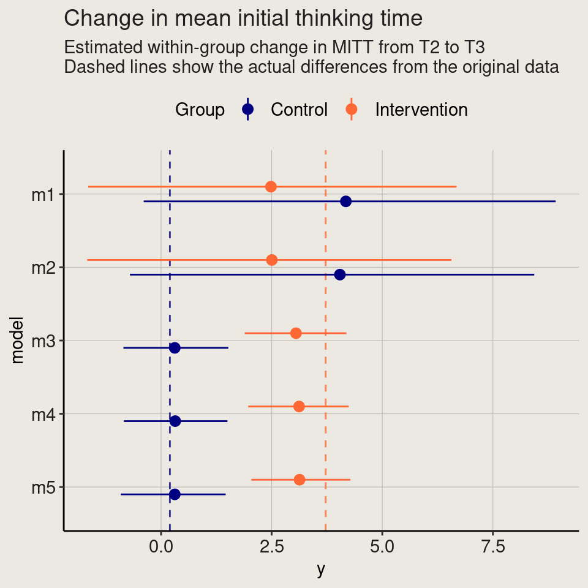

```r
p2
```

## 5.3 Estimated within-group change from T1 to T3

Again, the impact of a robust likelihood is evident, but the lower bound of the 95% CrI for `m5` is also closer to the actual difference for the intervention group, suggesting that multiple imputation and informative priors might have had an effect.

[figure not shown]

```r
p3
```